# PD_project_ensemble_Kiri

https://github.com/GreatLearningAIML1/gl-pgp-aiml-uta-intl-may20-kv2001

```python
import warnings
warnings.filterwarnings('ignore')
```

```python
import pandas as pd
import numpy as np
import matplotlib.pyplot as plt
%matplotlib inline
# this is to enable plotting graphs in Jupyter notebook
import seaborn as sns
# Remove scientific notations and display numbers with 2 decimal points instead
pd.options.display.float_format = '{:,.2f}'.format
from sklearn import metrics
from sklearn.tree import DecisionTreeClassifier
```

```python
#load the data file from local directory using pd.read_csv which is a formatted with comma separation
person_df = pd.read_csv("parkinsons.data")
person_df.head()
```

|  | name | MDVP:Fo(Hz) | MDVP:Fhi(Hz) | MDVP:Flo(Hz) | MDVP:Jitter(%) | MDVP:Jitter(Abs) | MDVP:RAP | MDVP:PPQ | Jitter:DDP | MDVP:Shimmer | ... | Shimmer:DDA | NHR | HNR | status | RPDE | DFA | spread1 | spread2 | D2 | PPE |
| --- | --- | --- | --- | --- | --- | --- | --- | --- | --- | --- | --- | --- | --- | --- | --- | --- | --- | --- | --- | --- | --- |
| 0 | phon_R01_S01_1 | 119.99 | 157.30 | 75.00 | 0.01 | 0.00 | 0.00 | 0.01 | 0.01 | 0.04 | ... | 0.07 | 0.02 | 21.03 | 1 | 0.41 | 0.82 | -4.81 | 0.27 | 2.30 | 0.28 |
| 1 | phon_R01_S01_2 | 122.40 | 148.65 | 113.82 | 0.01 | 0.00 | 0.00 | 0.01 | 0.01 | 0.06 | ... | 0.09 | 0.02 | 19.09 | 1 | 0.46 | 0.82 | -4.08 | 0.34 | 2.49 | 0.37 |
| 2 | phon_R01_S01_3 | 116.68 | 131.11 | 111.56 | 0.01 | 0.00 | 0.01 | 0.01 | 0.02 | 0.05 | ... | 0.08 | 0.01 | 20.65 | 1 | 0.43 | 0.83 | -4.44 | 0.31 | 2.34 | 0.33 |
| 3 | phon_R01_S01_4 | 116.68 | 137.87 | 111.37 | 0.01 | 0.00 | 0.01 | 0.01 | 0.02 | 0.05 | ... | 0.09 | 0.01 | 20.64 | 1 | 0.43 | 0.82 | -4.12 | 0.33 | 2.41 | 0.37 |
| 4 | phon_R01_S01_5 | 116.01 | 141.78 | 110.66 | 0.01 | 0.00 | 0.01 | 0.01 | 0.02 | 0.06 | ... | 0.10 | 0.02 | 19.65 | 1 | 0.42 | 0.82 | -3.75 | 0.23 | 2.33 | 0.41 |

5 rows × 24 columns

```python
person_df.shape
```

```
(195, 24)
```

Deliverable - 1 (EDA)

Univariate

```python
person_df.info()
```

```
<class 'pandas.core.frame.DataFrame'>
RangeIndex: 195 entries, 0 to 194
Data columns (total 24 columns):
 #   Column            Non-Null Count  Dtype
---  ------            --------------  -----
 0   name              195 non-null    object
 1   MDVP:Fo(Hz)       195 non-null    float64
 2   MDVP:Fhi(Hz)      195 non-null    float64
 3   MDVP:Flo(Hz)      195 non-null    float64
 4   MDVP:Jitter(%)    195 non-null    float64
 5   MDVP:Jitter(Abs)  195 non-null    float64
 6   MDVP:RAP          195 non-null    float64
 7   MDVP:PPQ          195 non-null    float64
 8   Jitter:DDP        195 non-null    float64
 9   MDVP:Shimmer      195 non-null    float64
```

[output cut: 16 more lines]

For all numberical columns

```python
person_df.describe()
```

|  | MDVP:Fo(Hz) | MDVP:Fhi(Hz) | MDVP:Flo(Hz) | MDVP:Jitter(%) | MDVP:Jitter(Abs) | MDVP:RAP | MDVP:PPQ | Jitter:DDP | MDVP:Shimmer | MDVP:Shimmer(dB) | ... | Shimmer:DDA | NHR | HNR | status | RPDE | DFA | spread1 | spread2 | D2 | PPE |
| --- | --- | --- | --- | --- | --- | --- | --- | --- | --- | --- | --- | --- | --- | --- | --- | --- | --- | --- | --- | --- | --- |
| count | 195.00 | 195.00 | 195.00 | 195.00 | 195.00 | 195.00 | 195.00 | 195.00 | 195.00 | 195.00 | ... | 195.00 | 195.00 | 195.00 | 195.00 | 195.00 | 195.00 | 195.00 | 195.00 | 195.00 | 195.00 |
| mean | 154.23 | 197.10 | 116.32 | 0.01 | 0.00 | 0.00 | 0.00 | 0.01 | 0.03 | 0.28 | ... | 0.05 | 0.02 | 21.89 | 0.75 | 0.50 | 0.72 | -5.68 | 0.23 | 2.38 | 0.21 |
| std | 41.39 | 91.49 | 43.52 | 0.00 | 0.00 | 0.00 | 0.00 | 0.01 | 0.02 | 0.19 | ... | 0.03 | 0.04 | 4.43 | 0.43 | 0.10 | 0.06 | 1.09 | 0.08 | 0.38 | 0.09 |
| min | 88.33 | 102.14 | 65.48 | 0.00 | 0.00 | 0.00 | 0.00 | 0.00 | 0.01 | 0.09 | ... | 0.01 | 0.00 | 8.44 | 0.00 | 0.26 | 0.57 | -7.96 | 0.01 | 1.42 | 0.04 |
| 25% | 117.57 | 134.86 | 84.29 | 0.00 | 0.00 | 0.00 | 0.00 | 0.00 | 0.02 | 0.15 | ... | 0.02 | 0.01 | 19.20 | 1.00 | 0.42 | 0.67 | -6.45 | 0.17 | 2.10 | 0.14 |
| 50% | 148.79 | 175.83 | 104.31 | 0.00 | 0.00 | 0.00 | 0.00 | 0.01 | 0.02 | 0.22 | ... | 0.04 | 0.01 | 22.09 | 1.00 | 0.50 | 0.72 | -5.72 | 0.22 | 2.36 | 0.19 |
| 75% | 182.77 | 224.21 | 140.02 | 0.01 | 0.00 | 0.00 | 0.00 | 0.01 | 0.04 | 0.35 | ... | 0.06 | 0.03 | 25.08 | 1.00 | 0.59 | 0.76 | -5.05 | 0.28 | 2.64 | 0.25 |
| max | 260.11 | 592.03 | 239.17 | 0.03 | 0.00 | 0.02 | 0.02 | 0.06 | 0.12 | 1.30 | ... | 0.17 | 0.31 | 33.05 | 1.00 | 0.69 | 0.83 | -2.43 | 0.45 | 3.67 | 0.53 |

8 rows × 23 columns

```python
person_df.isnull().sum(axis=0)
```

```
name                0
MDVP:Fo(Hz)         0
MDVP:Fhi(Hz)        0
MDVP:Flo(Hz)        0
MDVP:Jitter(%)      0
MDVP:Jitter(Abs)    0
MDVP:RAP            0
MDVP:PPQ            0
Jitter:DDP          0
MDVP:Shimmer        0
MDVP:Shimmer(dB)    0
Shimmer:APQ3        0
Shimmer:APQ5        0
MDVP:APQ            0
Shimmer:DDA         0
NHR                 0
HNR                 0
status              0
RPDE                0
DFA                 0
spread1             0
spread2             0
D2                  0
PPE                 0
dtype: int64
```

```python
person_df.skew()
```

```
MDVP:Fo(Hz)         0.59
MDVP:Fhi(Hz)        2.54
MDVP:Flo(Hz)        1.22
MDVP:Jitter(%)      3.08
MDVP:Jitter(Abs)    2.65
MDVP:RAP            3.36
MDVP:PPQ            3.07
Jitter:DDP          3.36
MDVP:Shimmer        1.67
MDVP:Shimmer(dB)    2.00
Shimmer:APQ3        1.58
Shimmer:APQ5        1.80
MDVP:APQ            2.62
Shimmer:DDA         1.58
NHR                 4.22
HNR                -0.51
status             -1.19
RPDE               -0.14
DFA                -0.03
spread1             0.43
spread2             0.14
D2                  0.43
PPE                 0.80
dtype: float64
```

The distribution of many variables are skewed and we may need transformation or bin treatment to normalize.

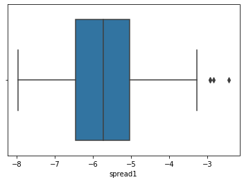

```python
sns.boxplot(person_df['spread1'])
plt.show()
```

'spread1' values above -3 seems to be outliers

```python
person_df[person_df['spread1']> -3.4]
```

|  | name | MDVP:Fo(Hz) | MDVP:Fhi(Hz) | MDVP:Flo(Hz) | MDVP:Jitter(%) | MDVP:Jitter(Abs) | MDVP:RAP | MDVP:PPQ | Jitter:DDP | MDVP:Shimmer | ... | Shimmer:DDA | NHR | HNR | status | RPDE | DFA | spread1 | spread2 | D2 | PPE |
| --- | --- | --- | --- | --- | --- | --- | --- | --- | --- | --- | --- | --- | --- | --- | --- | --- | --- | --- | --- | --- | --- |
| 17 | phon_R01_S04_6 | 168.78 | 232.18 | 75.60 | 0.01 | 0.00 | 0.00 | 0.00 | 0.01 | 0.03 | ... | 0.04 | 0.03 | 20.38 | 1 | 0.63 | 0.61 | -2.93 | 0.43 | 3.01 | 0.43 |
| 102 | phon_R01_S24_6 | 139.22 | 586.57 | 66.16 | 0.03 | 0.00 | 0.02 | 0.02 | 0.06 | 0.09 | ... | 0.17 | 0.26 | 10.49 | 1 | 0.60 | 0.64 | -3.27 | 0.27 | 2.69 | 0.44 |
| 146 | phon_R01_S35_1 | 169.77 | 191.76 | 151.45 | 0.02 | 0.00 | 0.01 | 0.01 | 0.03 | 0.08 | ... | 0.11 | 0.08 | 12.36 | 1 | 0.56 | 0.79 | -3.30 | 0.41 | 3.41 | 0.46 |
| 148 | phon_R01_S35_3 | 188.62 | 216.30 | 165.98 | 0.02 | 0.00 | 0.01 | 0.01 | 0.03 | 0.07 | ... | 0.10 | 0.08 | 12.30 | 1 | 0.55 | 0.76 | -3.38 | 0.34 | 3.27 | 0.42 |
| 151 | phon_R01_S35_6 | 192.82 | 224.43 | 168.79 | 0.03 | 0.00 | 0.02 | 0.02 | 0.05 | 0.12 | ... | 0.17 | 0.22 | 8.44 | 1 | 0.63 | 0.77 | -2.43 | 0.45 | 3.08 | 0.53 |
| 152 | phon_R01_S35_7 | 198.12 | 233.10 | 174.48 | 0.03 | 0.00 | 0.02 | 0.02 | 0.05 | 0.09 | ... | 0.13 | 0.16 | 9.45 | 1 | 0.58 | 0.75 | -2.84 | 0.36 | 3.18 | 0.45 |
| 164 | phon_R01_S39_6 | 102.27 | 142.83 | 85.90 | 0.01 | 0.00 | 0.00 | 0.00 | 0.01 | 0.03 | ... | 0.05 | 0.04 | 18.45 | 1 | 0.67 | 0.67 | -2.93 | 0.40 | 2.56 | 0.37 |

7 rows × 24 columns

remove outliers

```python
person_df.drop(index=person_df[person_df['spread1']>-3].index,  axis=0, inplace=True)
```

```python
person_df.shape
```

```
(191, 24)
```

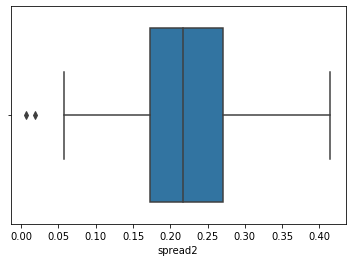

```python
sns.boxplot(person_df['spread2'])
plt.show()
```

```python
person_df[person_df['spread2']< 0.05]
person_df[person_df['spread2']> 0.4]
```

|  | name | MDVP:Fo(Hz) | MDVP:Fhi(Hz) | MDVP:Flo(Hz) | MDVP:Jitter(%) | MDVP:Jitter(Abs) | MDVP:RAP | MDVP:PPQ | Jitter:DDP | MDVP:Shimmer | ... | Shimmer:DDA | NHR | HNR | status | RPDE | DFA | spread1 | spread2 | D2 | PPE |
| --- | --- | --- | --- | --- | --- | --- | --- | --- | --- | --- | --- | --- | --- | --- | --- | --- | --- | --- | --- | --- | --- |
| 146 | phon_R01_S35_1 | 169.77 | 191.76 | 151.45 | 0.02 | 0.00 | 0.01 | 0.01 | 0.03 | 0.08 | ... | 0.11 | 0.08 | 12.36 | 1 | 0.56 | 0.79 | -3.30 | 0.41 | 3.41 | 0.46 |

1 rows × 24 columns

```python
person_df.drop(index=person_df[person_df['spread2']<0.05].index,  axis=0, inplace=True)
person_df.drop(index=person_df[person_df['spread2']>0.4].index,  axis=0, inplace=True)
```

```python
person_df.shape
```

```
(188, 24)
```

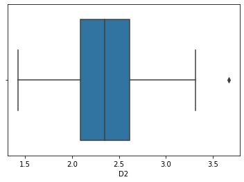

```python
sns.boxplot(person_df['D2'])
plt.show()
```

values >3.5 in D2 seems to have outliers.

```python
person_df[person_df['D2']>3.5]
```

|  | name | MDVP:Fo(Hz) | MDVP:Fhi(Hz) | MDVP:Flo(Hz) | MDVP:Jitter(%) | MDVP:Jitter(Abs) | MDVP:RAP | MDVP:PPQ | Jitter:DDP | MDVP:Shimmer | ... | Shimmer:DDA | NHR | HNR | status | RPDE | DFA | spread1 | spread2 | D2 | PPE |
| --- | --- | --- | --- | --- | --- | --- | --- | --- | --- | --- | --- | --- | --- | --- | --- | --- | --- | --- | --- | --- | --- |
| 89 | phon_R01_S21_6 | 179.71 | 225.93 | 144.88 | 0.01 | 0.00 | 0.00 | 0.00 | 0.01 | 0.04 | ... | 0.07 | 0.07 | 11.87 | 1 | 0.59 | 0.75 | -4.38 | 0.38 | 3.67 | 0.33 |

1 rows × 24 columns

```python
person_df.drop(index=person_df[person_df['D2']>3.5].index,  axis=0, inplace=True)
```

```python
person_df.shape
```

```
(187, 24)
```

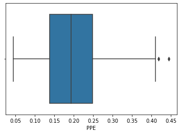

```python
sns.boxplot(person_df['PPE'])
plt.show()
```

PPE values >0.41 have seems to have outliers

```python
person_df[person_df['PPE']>0.41]
```

|  | name | MDVP:Fo(Hz) | MDVP:Fhi(Hz) | MDVP:Flo(Hz) | MDVP:Jitter(%) | MDVP:Jitter(Abs) | MDVP:RAP | MDVP:PPQ | Jitter:DDP | MDVP:Shimmer | ... | Shimmer:DDA | NHR | HNR | status | RPDE | DFA | spread1 | spread2 | D2 | PPE |
| --- | --- | --- | --- | --- | --- | --- | --- | --- | --- | --- | --- | --- | --- | --- | --- | --- | --- | --- | --- | --- | --- |
| 4 | phon_R01_S01_5 | 116.01 | 141.78 | 110.66 | 0.01 | 0.00 | 0.01 | 0.01 | 0.02 | 0.06 | ... | 0.10 | 0.02 | 19.65 | 1 | 0.42 | 0.82 | -3.75 | 0.23 | 2.33 | 0.41 |
| 102 | phon_R01_S24_6 | 139.22 | 586.57 | 66.16 | 0.03 | 0.00 | 0.02 | 0.02 | 0.06 | 0.09 | ... | 0.17 | 0.26 | 10.49 | 1 | 0.60 | 0.64 | -3.27 | 0.27 | 2.69 | 0.44 |
| 148 | phon_R01_S35_3 | 188.62 | 216.30 | 165.98 | 0.02 | 0.00 | 0.01 | 0.01 | 0.03 | 0.07 | ... | 0.10 | 0.08 | 12.30 | 1 | 0.55 | 0.76 | -3.38 | 0.34 | 3.27 | 0.42 |

3 rows × 24 columns

```python
person_df.drop(index=person_df[person_df['PPE']>0.41].index,  axis=0, inplace=True)
```

```python
person_df.drop(['name'], axis=1, inplace=True)
```

```python
person_df.shape
```

```
(184, 23)
```

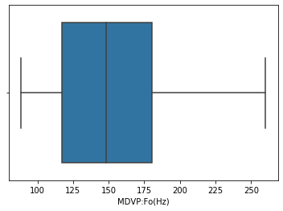

```python
sns.boxplot(person_df['MDVP:Fo(Hz)'])
plt.show()
```

no outliers in MDVP:Fo(Hz) detected

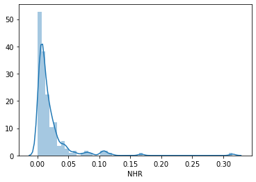

```python
sns.distplot(person_df['NHR'])
plt.show()
```

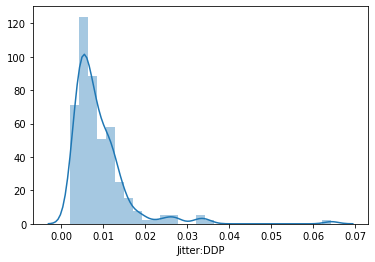

```python
sns.distplot(person_df['Jitter:DDP'])
plt.show()
```

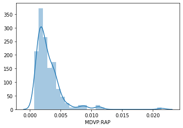

```python
sns.distplot(person_df['MDVP:RAP'])
plt.show()
```

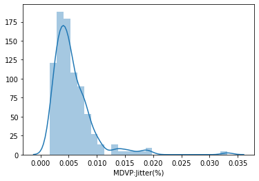

```python
sns.distplot(person_df['MDVP:Jitter(%)'])
plt.show()
```

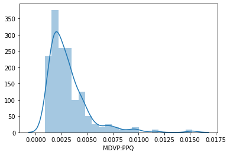

```python
sns.distplot(person_df['MDVP:PPQ'])
plt.show()
```

non-numerical columns treatment is not needed in this case study.

```python
person_df['status'].value_counts(normalize=True)*100
```

```
1   75.00
0   25.00
Name: status, dtype: float64
```

```python
len(person_df)
```

```
184
```

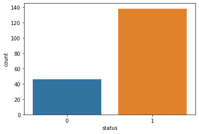

```python
sns.countplot(person_df['status'])
plt.show()
```

```python
person_df['status'].value_counts()
```

```
1    138
0     46
Name: status, dtype: int64
```

`The healthy response rate is only 25%. Hence the Y variable has a high class imbalance. Hence accuracy will not be a reliable model performance measure.`

`FN is very critical for this business case because a false negative is a person who will potentially may diagonose to have parkinson but who has been classified as 'healthy'. Hence the most relevant model performance measure is recall`

### Bivariate analysis

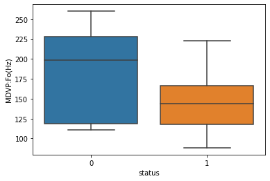

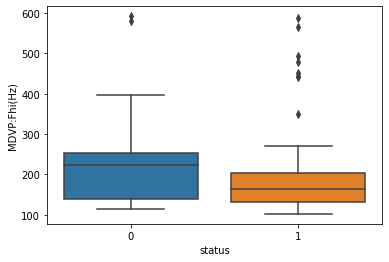

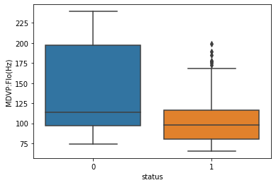

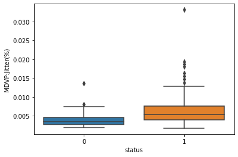

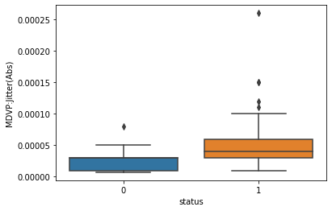

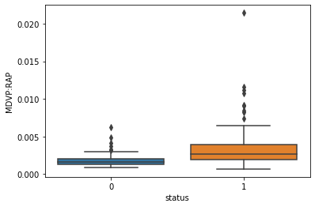

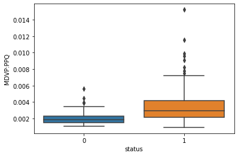

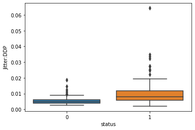

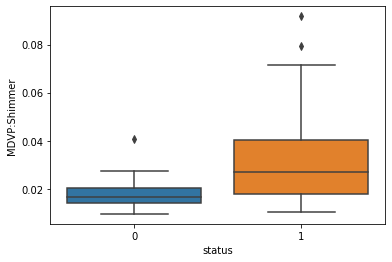

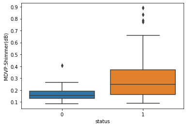

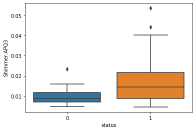

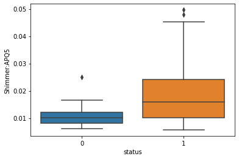

[10 more figures not shown]

```python
for i in ['MDVP:Fo(Hz)','MDVP:Fhi(Hz)','MDVP:Flo(Hz)','MDVP:Jitter(%)','MDVP:Jitter(Abs)','MDVP:RAP','MDVP:PPQ','Jitter:DDP','MDVP:Shimmer','MDVP:Shimmer(dB)','Shimmer:APQ3','Shimmer:APQ5','MDVP:APQ','Shimmer:DDA','NHR','HNR','RPDE','DFA','spread1','spread2','D2','PPE']:
    sns.boxplot(x='status',y=i,data=person_df)
    plt.show()
```

```python
#Group numerical variables by mean for the classes of Y variable
np.round(person_df.groupby(["status"]).mean() ,1)
```

| status | MDVP:Fo(Hz) | MDVP:Fhi(Hz) | MDVP:Flo(Hz) | MDVP:Jitter(%) | MDVP:Jitter(Abs) | MDVP:RAP | MDVP:PPQ | Jitter:DDP | MDVP:Shimmer | MDVP:Shimmer(dB) | ... | MDVP:APQ | Shimmer:DDA | NHR | HNR | RPDE | DFA | spread1 | spread2 | D2 | PPE |
| --- | --- | --- | --- | --- | --- | --- | --- | --- | --- | --- | --- | --- | --- | --- | --- | --- | --- | --- | --- | --- | --- |
| 0 | 179.90 | 223.10 | 144.20 | 0.00 | 0.00 | 0.00 | 0.00 | 0.00 | 0.00 | 0.20 | ... | 0.00 | 0.00 | 0.00 | 24.70 | 0.40 | 0.70 | -6.70 | 0.20 | 2.10 | 0.10 |
| 1 | 144.10 | 184.80 | 105.60 | 0.00 | 0.00 | 0.00 | 0.00 | 0.00 | 0.00 | 0.30 | ... | 0.00 | 0.00 | 0.00 | 21.40 | 0.50 | 0.70 | -5.50 | 0.20 | 2.40 | 0.20 |

2 rows × 22 columns

'the mean values of MDVP:Fo(Hz), MDVP:Fhi(Hz) & MDVP:Fho(Hz) are higher for healthy persons compared to parkinsons symptoms persons'

'the mean value PPE is lower for healthy persons compared to parkinsons symptoms persons'

'the mean value spread1 is lower for healthy persons compared to parkinsons symptoms persons'

'All of the above facts indicate for the lower mean values for MDVP:Fo(Hz) MDVP:Fhi(Hz). and MDVP:Flo(Hz) indicate parkinsons symtoms'

```python
person_df.corr()
```

|  | MDVP:Fo(Hz) | MDVP:Fhi(Hz) | MDVP:Flo(Hz) | MDVP:Jitter(%) | MDVP:Jitter(Abs) | MDVP:RAP | MDVP:PPQ | Jitter:DDP | MDVP:Shimmer | MDVP:Shimmer(dB) | ... | Shimmer:DDA | NHR | HNR | status | RPDE | DFA | spread1 | spread2 | D2 | PPE |
| --- | --- | --- | --- | --- | --- | --- | --- | --- | --- | --- | --- | --- | --- | --- | --- | --- | --- | --- | --- | --- | --- |
| MDVP:Fo(Hz) | 1.00 | 0.42 | 0.59 | -0.21 | -0.46 | -0.15 | -0.22 | -0.15 | -0.16 | -0.15 | ... | -0.14 | -0.07 | 0.10 | -0.38 | -0.39 | -0.48 | -0.50 | -0.27 | 0.15 | -0.48 |
| MDVP:Fhi(Hz) | 0.42 | 1.00 | 0.11 | -0.03 | -0.17 | -0.04 | -0.04 | -0.04 | -0.11 | -0.06 | ... | -0.12 | 0.03 | 0.05 | -0.19 | -0.14 | -0.34 | -0.16 | -0.02 | 0.17 | -0.17 |
| MDVP:Flo(Hz) | 0.59 | 0.11 | 1.00 | -0.25 | -0.35 | -0.20 | -0.23 | -0.20 | -0.24 | -0.23 | ... | -0.23 | -0.18 | 0.29 | -0.39 | -0.41 | -0.09 | -0.50 | -0.29 | -0.18 | -0.46 |
| MDVP:Jitter(%) | -0.21 | -0.03 | -0.25 | 1.00 | 0.94 | 0.98 | 0.96 | 0.98 | 0.66 | 0.69 | ... | 0.64 | 0.87 | -0.67 | 0.28 | 0.36 | 0.08 | 0.64 | 0.29 | 0.37 | 0.64 |
| MDVP:Jitter(Abs) | -0.46 | -0.17 | -0.35 | 0.94 | 1.00 | 0.91 | 0.91 | 0.91 | 0.61 | 0.63 | ... | 0.60 | 0.79 | -0.60 | 0.33 | 0.44 | 0.19 | 0.70 | 0.32 | 0.25 | 0.71 |
| MDVP:RAP | -0.15 | -0.04 | -0.20 | 0.98 | 0.91 | 1.00 | 0.94 | 1.00 | 0.65 | 0.68 | ... | 0.64 | 0.89 | -0.67 | 0.26 | 0.33 | 0.04 | 0.58 | 0.22 | 0.36 | 0.58 |
| MDVP:PPQ | -0.22 | -0.04 | -0.23 | 0.96 | 0.91 | 0.94 | 1.00 | 0.94 | 0.70 | 0.74 | ... | 0.67 | 0.78 | -0.69 | 0.30 | 0.34 | 0.20 | 0.68 | 0.32 | 0.33 | 0.72 |
| Jitter:DDP | -0.15 | -0.04 | -0.20 | 0.98 | 0.91 | 1.00 | 0.94 | 1.00 | 0.65 | 0.68 | ... | 0.64 | 0.89 | -0.67 | 0.26 | 0.33 | 0.04 | 0.58 | 0.22 | 0.36 | 0.58 |
| MDVP:Shimmer | -0.16 | -0.11 | -0.24 | 0.66 | 0.61 | 0.65 | 0.70 | 0.65 | 1.00 | 0.98 | ... | 0.99 | 0.62 | -0.81 | 0.37 | 0.46 | 0.13 | 0.58 | 0.38 | 0.45 | 0.60 |
| MDVP:Shimmer(dB) | -0.15 | -0.06 | -0.23 | 0.69 | 0.63 | 0.68 | 0.74 | 0.68 | 0.98 | 1.00 | ... | 0.96 | 0.64 | -0.80 | 0.36 | 0.42 | 0.14 | 0.57 | 0.37 | 0.44 | 0.59 |
| Shimmer:APQ3 | -0.14 | -0.12 | -0.23 | 0.64 | 0.60 | 0.64 | 0.67 | 0.64 | 0.99 | 0.96 | ... | 1.00 | 0.62 | -0.80 | 0.34 | 0.44 | 0.12 | 0.53 | 0.33 | 0.41 | 0.55 |
| Shimmer:APQ5 | -0.14 | -0.10 | -0.21 | 0.60 | 0.55 | 0.58 | 0.68 | 0.58 | 0.98 | 0.97 | ... | 0.96 | 0.55 | -0.79 | 0.36 | 0.42 | 0.18 | 0.57 | 0.39 | 0.44 | 0.61 |
| MDVP:APQ | -0.18 | -0.09 | -0.26 | 0.64 | 0.58 | 0.62 | 0.69 | 0.62 | 0.96 | 0.96 | ... | 0.91 | 0.60 | -0.80 | 0.40 | 0.49 | 0.11 | 0.62 | 0.43 | 0.48 | 0.64 |
| Shimmer:DDA | -0.14 | -0.12 | -0.23 | 0.64 | 0.60 | 0.64 | 0.67 | 0.64 | 0.99 | 0.96 | ... | 1.00 | 0.62 | -0.80 | 0.34 | 0.44 | 0.12 | 0.53 | 0.33 | 0.41 | 0.55 |
| NHR | -0.07 | 0.03 | -0.18 | 0.87 | 0.79 | 0.89 | 0.78 | 0.89 | 0.62 | 0.64 | ... | 0.62 | 1.00 | -0.66 | 0.17 | 0.36 | -0.19 | 0.45 | 0.22 | 0.43 | 0.43 |
| HNR | 0.10 | 0.05 | 0.29 | -0.67 | -0.60 | -0.67 | -0.69 | -0.67 | -0.81 | -0.80 | ... | -0.80 | -0.66 | 1.00 | -0.34 | -0.60 | 0.04 | -0.61 | -0.34 | -0.53 | -0.62 |
| status | -0.38 | -0.19 | -0.39 | 0.28 | 0.33 | 0.26 | 0.30 | 0.26 | 0.37 | 0.36 | ... | 0.34 | 0.17 | -0.34 | 1.00 | 0.27 | 0.23 | 0.58 | 0.42 | 0.33 | 0.55 |
| RPDE | -0.39 | -0.14 | -0.41 | 0.36 | 0.44 | 0.33 | 0.34 | 0.33 | 0.46 | 0.42 | ... | 0.44 | 0.36 | -0.60 | 0.27 | 1.00 | -0.12 | 0.58 | 0.41 | 0.19 | 0.54 |
| DFA | -0.48 | -0.34 | -0.09 | 0.08 | 0.19 | 0.04 | 0.20 | 0.04 | 0.13 | 0.14 | ... | 0.12 | -0.19 | 0.04 | 0.23 | -0.12 | 1.00 | 0.21 | 0.17 | -0.22 | 0.29 |
| spread1 | -0.50 | -0.16 | -0.50 | 0.64 | 0.70 | 0.58 | 0.68 | 0.58 | 0.58 | 0.57 | ... | 0.53 | 0.45 | -0.61 | 0.58 | 0.58 | 0.21 | 1.00 | 0.57 | 0.41 | 0.95 |
| spread2 | -0.27 | -0.02 | -0.29 | 0.29 | 0.32 | 0.22 | 0.32 | 0.22 | 0.38 | 0.37 | ... | 0.33 | 0.22 | -0.34 | 0.42 | 0.41 | 0.17 | 0.57 | 1.00 | 0.46 | 0.57 |
| D2 | 0.15 | 0.17 | -0.18 | 0.37 | 0.25 | 0.36 | 0.33 | 0.36 | 0.45 | 0.44 | ... | 0.41 | 0.43 | -0.53 | 0.33 | 0.19 | -0.22 | 0.41 | 0.46 | 1.00 | 0.38 |
| PPE | -0.48 | -0.17 | -0.46 | 0.64 | 0.71 | 0.58 | 0.72 | 0.58 | 0.60 | 0.59 | ... | 0.55 | 0.43 | -0.62 | 0.55 | 0.54 | 0.29 | 0.95 | 0.57 | 0.38 | 1.00 |

23 rows × 23 columns

Check for correlation between variables whose values are >0.8

Observations:

There are correlation relationships between many two variables such as NHR & MDVP:Jitter(%) , NHR & MDVP:RAP , NHR & Jitter:DDP, MDVP:RAP & MDVP:Jitter(%), MDVP:PPQ & MDVP:Jitter(%), Jitter:DDP & MDVP:Jitter(%), MDVP:Jitter(Abs) &MDVP:PPQ, MDVP:RAP & MDVP:Jitter(Abs), Jitter:DDP & MDVP:Jitter(Abs)

There is no strong correlation between any independent variable and class variable(status).

Split the person_df into training and test set in the ratio of 70:30 (Training:Test).

```python
from sklearn.model_selection import train_test_split
test_size = 0.30 # taking 70:30 training and test set
seed = 7  # Random numbmer seeding for reapeatability of the code
y = person_df["status"].values
```

```python
#all dummies

def get_model_data(df):

    X = person_df.drop("status" , axis=1)
    X = pd.get_dummies(X, drop_first=True)

    X_train, X_test, y_train, y_test = train_test_split(X, y, test_size=test_size, random_state=seed)


    return X_train, X_test, y_train, y_test
```

```python
X_train, X_test, y_train, y_test = get_model_data(person_df)
```

```python
X_train.shape,X_test.shape
```

```
((128, 22), (56, 22))
```

Create the decision tree model using “entropy” method of reducing the entropy and fit it to training data.

```python
dTree = DecisionTreeClassifier(criterion = 'entropy', random_state=1)
dTree.fit(X_train, y_train)
```

```
DecisionTreeClassifier(ccp_alpha=0.0, class_weight=None, criterion='entropy',
                       max_depth=None, max_features=None, max_leaf_nodes=None,
                       min_impurity_decrease=0.0, min_impurity_split=None,
                       min_samples_leaf=1, min_samples_split=2,
                       min_weight_fraction_leaf=0.0, presort='deprecated',
                       random_state=1, splitter='best')
```

Print the accuracy of the model & print the confusion matrix

```python
print(dTree.score(X_train, y_train))
print(dTree.score(X_test, y_test))
```

```
1.0
0.8928571428571429
```

```python
print (pd.DataFrame(dTree.feature_importances_, columns = ["Imp"], index = X_train.columns))
#Print the feature importance of the decision model
```

```
                  Imp
MDVP:Fo(Hz)      0.23
MDVP:Fhi(Hz)     0.00
MDVP:Flo(Hz)     0.10
MDVP:Jitter(%)   0.00
MDVP:Jitter(Abs) 0.00
MDVP:RAP         0.00
MDVP:PPQ         0.00
Jitter:DDP       0.00
MDVP:Shimmer     0.15
MDVP:Shimmer(dB) 0.03
Shimmer:APQ3     0.08
Shimmer:APQ5     0.05
MDVP:APQ         0.00
Shimmer:DDA      0.00
NHR              0.00
HNR              0.00
RPDE             0.00
DFA              0.00
spread1          0.00
spread2          0.00
D2               0.00
PPE              0.37
```

Reducing over fitting

```python
dTreeR = DecisionTreeClassifier(criterion = 'entropy', max_depth = 3, random_state=1)
dTreeR.fit(X_train, y_train)
print(dTreeR.score(X_train, y_train))
print(dTreeR.score(X_test, y_test))
```

```
0.9765625
0.8928571428571429
```

```
0.8928571428571429
```

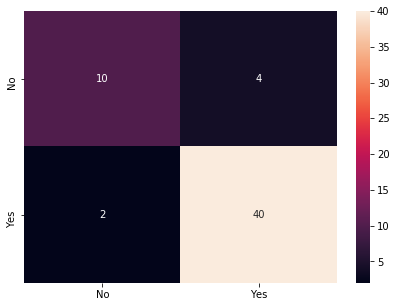

```python
print(dTreeR.score(X_test , y_test))
y_predict = dTree.predict(X_test)

cm=metrics.confusion_matrix(y_test, y_predict, labels=[0, 1])

df_cm = pd.DataFrame(cm, index = [i for i in ["No","Yes"]],
                  columns = [i for i in ["No","Yes"]])
plt.figure(figsize = (7,5))
sns.heatmap(df_cm, annot=True ,fmt='g')
```

Apply the Random forest model and print the accuracy of Random forest Model

```python
from sklearn.ensemble import RandomForestClassifier
rfcl = RandomForestClassifier(criterion = 'entropy', class_weight={0:.5,1:.5}, max_depth = 5, min_samples_leaf=5)
rfcl = rfcl.fit(X_train, y_train)
test_pred = rfcl.predict(X_test)
rfcl.score(X_test , y_test)
```

```
0.8392857142857143
```

Apply Adaboost Ensemble Algorithm for the same data and print the accuracy.

```python
from sklearn.ensemble import AdaBoostClassifier
#abcl = AdaBoostClassifier(base_estimator=dt_model, n_estimators=50)
abcl = AdaBoostClassifier( n_estimators= 20)
abcl = abcl.fit(X_train, y_train)

test_pred = abcl.predict(X_test)
abcl.score(X_test , y_test)
```

```
0.9107142857142857
```

Apply Bagging Classifier Algorithm and print the accuracy.

```python
from sklearn.ensemble import BaggingClassifier

bgcl = BaggingClassifier(n_estimators=10, max_samples= .7, bootstrap=True)
bgcl = bgcl.fit(X_train, y_train)
```

```python
test_pred = bgcl.predict(X_test)
bgcl.score(X_test , y_test)
```

```
0.8214285714285714
```

Apply GradientBoost Classifier Algorithm for the same data and print the accuracy

```python
from sklearn.ensemble import GradientBoostingClassifier
gbcl = GradientBoostingClassifier(n_estimators = 50, learning_rate = 0.05)
gbcl = gbcl.fit(X_train, y_train)
```

```python
test_pred = gbcl.predict(X_test)
gbcl.score(X_test , y_test)
```

```
0.9285714285714286
```

```python
from sklearn.model_selection import GridSearchCV, RandomizedSearchCV
from sklearn.metrics import recall_score, precision_score, roc_auc_score, accuracy_score, make_scorer, f1_score, confusion_matrix
from sklearn.ensemble import GradientBoostingClassifier, RandomForestClassifier
import xgboost as xgb
```

```python
def get_recall_score(learning_rate, min_samples_leaf, n_estimators):

    model = GradientBoostingClassifier(**{'learning_rate': learning_rate,
                  'min_samples_leaf': min_samples_leaf,
                  'n_estimators': n_estimators})
    model.fit(X_train, y_train)
    return [learning_rate,min_samples_leaf,n_estimators,recall_score(y_train, model.predict(X_train)),
    recall_score(y_test, model.predict(X_test))]
```

```python
import multiprocessing
from itertools import product
```

```python
%%time

import multiprocessing
from itertools import product

process_pool = multiprocessing.Pool(8)

learning_rate = [0.1,0.01,0.001]
min_samples_leaf = [100,200,300]
n_estimators = [50,100,300]

data = product(learning_rate, min_samples_leaf, n_estimators)

output = process_pool.starmap(get_recall_score, data)
process_pool.close()
```

```
CPU times: user 12.2 ms, sys: 24.5 ms, total: 36.7 ms
Wall time: 244 ms
```

```python
print(pd.DataFrame(output, columns=['learning_rate','min_samples_leaf','n_estimators',
                                   'train','test']).sort_values(by='test', ascending=False))
```

```
    learning_rate  min_samples_leaf  n_estimators  train  test
0            0.10               100            50   1.00  1.00
14           0.01               200           300   1.00  1.00
25           0.00               300           100   1.00  1.00
24           0.00               300            50   1.00  1.00
23           0.00               200           300   1.00  1.00
22           0.00               200           100   1.00  1.00
21           0.00               200            50   1.00  1.00
20           0.00               100           300   1.00  1.00
19           0.00               100           100   1.00  1.00
18           0.00               100            50   1.00  1.00
17           0.01               300           300   1.00  1.00
16           0.01               300           100   1.00  1.00
15           0.01               300            50   1.00  1.00
13           0.01               200           100   1.00  1.00
1            0.10               100           100   1.00  1.00
12           0.01               200            50   1.00  1.00
11           0.01               100           300   1.00  1.00
10           0.01               100           100   1.00  1.00
9            0.01               100            50   1.00  1.00
8            0.10               300           300   1.00  1.00
7            0.10               300           100   1.00  1.00
6            0.10               300            50   1.00  1.00
5            0.10               200           300   1.00  1.00
4            0.10               200           100   1.00  1.00
3            0.10               200            50   1.00  1.00
2            0.10               100           300   1.00  1.00
26           0.00               300           300   1.00  1.00
```

Finding optimal threshold

```python
model = GradientBoostingClassifier(**{'learning_rate': 0.1,
              'min_samples_leaf': 100,
              'n_estimators': 300})
model.fit(X_train, y_train)
```

```
GradientBoostingClassifier(ccp_alpha=0.0, criterion='friedman_mse', init=None,
                           learning_rate=0.1, loss='deviance', max_depth=3,
                           max_features=None, max_leaf_nodes=None,
                           min_impurity_decrease=0.0, min_impurity_split=None,
                           min_samples_leaf=100, min_samples_split=2,
                           min_weight_fraction_leaf=0.0, n_estimators=300,
                           n_iter_no_change=None, presort='deprecated',
                           random_state=None, subsample=1.0, tol=0.0001,
                           validation_fraction=0.1, verbose=0,
                           warm_start=False)
```

```python
predictions = model.predict_proba(X_train)[:,1]
```

```python
predictions_df = pd.DataFrame({"actual":y_train,
                              "prediction":predictions})
```

```python
predictions_df.head()
```

|  | actual | prediction |
| --- | --- | --- |
| 0 | 1 | 0.75 |
| 1 | 1 | 0.75 |
| 2 | 1 | 0.75 |
| 3 | 1 | 0.75 |
| 4 | 0 | 0.75 |

```python
predictions_df['predicted'] = predictions_df['prediction'] >= 0.1
```

```python
recall_score(predictions_df['actual'], predictions_df['predicted'])
```

```
1.0
```

```python
predictions_df['predicted'] = predictions_df['prediction'] >= 0.2
```

```python
pd.DataFrame(confusion_matrix(predictions_df['actual'], predictions_df['predicted'])).to_clipboard()
```

```python
precision_score(predictions_df['actual'], predictions_df['predicted'])
```

```
0.75
```

```python
predictions_df['predicted'] = predictions_df['prediction'] >= 0.2
recall_score(predictions_df['actual'], predictions_df['predicted'])
```

```
1.0
```

```python
predictions_df['predicted'].mean()
```

```
1.0
```

```python
predictions = model.predict_proba(X_train)[:,1]

for i in [i/10 for i in range(1,10)]:
    predictions_df['predicted'] = predictions_df['prediction'] >= i
    print(i, recall_score(y_train, predictions_df['predicted']),
         precision_score(y_train, predictions_df['predicted']),
         f1_score(y_train, predictions_df['predicted']))
```

```
0.1 1.0 0.75 0.8571428571428571
0.2 1.0 0.75 0.8571428571428571
0.3 1.0 0.75 0.8571428571428571
0.4 1.0 0.75 0.8571428571428571
0.5 1.0 0.75 0.8571428571428571
0.6 1.0 0.75 0.8571428571428571
0.7 1.0 0.75 0.8571428571428571
0.8 0.0 0.0 0.0
0.9 0.0 0.0 0.0
```

```python
predictions_df['actual'].mean()
```

```
0.75
```

```python
def get_recall_score(min_samples_leaf, n_estimators):

    model = RandomForestClassifier(**{
                  'min_samples_leaf': min_samples_leaf,
                  'n_estimators': n_estimators,
    'n_jobs':-1})
    model.fit(X_train, y_train)
    return [min_samples_leaf,n_estimators,recall_score(y_train, model.predict(X_train)),
    recall_score(y_test, model.predict(X_test))]


process_pool = multiprocessing.Pool(8)
#data = product([100,200,300], [50,100,300], [0.1,0.01,0.001])

min_samples_leaf = [100,200,300]
n_estimators = [50,100,300]

data = product(min_samples_leaf, n_estimators)


output = process_pool.starmap(get_recall_score, data)
process_pool.close()
```

```python
print(pd.DataFrame(output, columns=['min_samples_leaf','n_estimators',
                                   'train','test']).sort_values(by='test', ascending=False))
```

```
   min_samples_leaf  n_estimators  train  test
0               100            50   1.00  1.00
1               100           100   1.00  1.00
2               100           300   1.00  1.00
3               200            50   1.00  1.00
4               200           100   1.00  1.00
5               200           300   1.00  1.00
6               300            50   1.00  1.00
7               300           100   1.00  1.00
8               300           300   1.00  1.00
```

```python
model = RandomForestClassifier(**{
              'min_samples_leaf': 100,
              'n_estimators': 300,
'n_jobs':-1})
model.fit(X_train, y_train)
predictions = model.predict_proba(X_train)[:,1]
predictions_df = pd.DataFrame({"actual":y_train,
                              "prediction":predictions})
for i in [i/10 for i in range(1,10)]:
    predictions_df['predicted'] = predictions_df['prediction'] >= i
    print(i, recall_score(y_train, predictions_df['predicted']),
         precision_score(y_train, predictions_df['predicted']),
         f1_score(y_train, predictions_df['predicted']))
```

```
0.1 1.0 0.75 0.8571428571428571
0.2 1.0 0.75 0.8571428571428571
0.3 1.0 0.75 0.8571428571428571
0.4 1.0 0.75 0.8571428571428571
0.5 1.0 0.75 0.8571428571428571
0.6 1.0 0.75 0.8571428571428571
0.7 1.0 0.75 0.8571428571428571
0.8 0.0 0.0 0.0
0.9 0.0 0.0 0.0
```

```python
def get_recall_score(learning_rate, min_samples_leaf, n_estimators):

    model = xgb.XGBClassifier(**{'learning_rate': learning_rate,
                  'min_samples_leaf': min_samples_leaf,
                  'n_estimators': n_estimators,
                                'n_jobs':-1})
    model.fit(X_train, y_train)
    return [learning_rate,min_samples_leaf,n_estimators,recall_score(y_train, model.predict(X_train)),
    recall_score(y_test, model.predict(X_test))]


process_pool = multiprocessing.Pool(8)
learning_rate = [0.1,0.01,0.001]
min_samples_leaf = [100,200,300]
n_estimators = [50,100,300]

data = product(learning_rate, min_samples_leaf, n_estimators)

output = process_pool.starmap(get_recall_score, data)
process_pool.close()
```

```python
print(pd.DataFrame(output, columns=['learning_rate','min_samples_leaf','n_estimators',
                                   'train','test']).sort_values(by='test', ascending=False))
```

```
    learning_rate  min_samples_leaf  n_estimators  train  test
0            0.10               100            50   1.00  0.98
14           0.01               200           300   0.99  0.98
2            0.10               100           300   1.00  0.98
3            0.10               200            50   1.00  0.98
4            0.10               200           100   1.00  0.98
5            0.10               200           300   1.00  0.98
6            0.10               300            50   1.00  0.98
7            0.10               300           100   1.00  0.98
8            0.10               300           300   1.00  0.98
17           0.01               300           300   0.99  0.98
11           0.01               100           300   0.99  0.98
1            0.10               100           100   1.00  0.98
21           0.00               200            50   0.97  0.95
22           0.00               200           100   0.97  0.95
25           0.00               300           100   0.97  0.95
23           0.00               200           300   0.97  0.95
24           0.00               300            50   0.97  0.95
19           0.00               100           100   0.97  0.95
20           0.00               100           300   0.97  0.95
13           0.01               200           100   0.97  0.95
18           0.00               100            50   0.97  0.95
16           0.01               300           100   0.97  0.95
15           0.01               300            50   0.97  0.95
12           0.01               200            50   0.97  0.95
10           0.01               100           100   0.97  0.95
9            0.01               100            50   0.97  0.95
26           0.00               300           300   0.97  0.95
```

```python
model = xgb.XGBClassifier(**{
                'learning_rate':0.1,
              'min_samples_leaf': 200,
              'n_estimators': 100,
'n_jobs':-1})
model.fit(X_train, y_train)
predictions = model.predict_proba(X_train)[:,1]
predictions_df = pd.DataFrame({"actual":y_train,
                              "prediction":predictions})
for i in [i/10 for i in range(1,10)]:
    predictions_df['predicted'] = predictions_df['prediction'] >= i
    print(i, recall_score(y_train, predictions_df['predicted']),
         precision_score(y_train, predictions_df['predicted']),
         f1_score(y_train, predictions_df['predicted']))
```

```
0.1 1.0 0.9504950495049505 0.9746192893401014
0.2 1.0 0.9795918367346939 0.9896907216494846
0.3 1.0 1.0 1.0
0.4 1.0 1.0 1.0
0.5 1.0 1.0 1.0
0.6 1.0 1.0 1.0
0.7 1.0 1.0 1.0
0.8 0.9895833333333334 1.0 0.9947643979057591
0.9 0.96875 1.0 0.9841269841269841
```

Confusion matrix means

True Positive (observed=1,predicted=1):

Person has symptoms to parkinsons and model predicted that the person has

False Positive (observed=0,predicted=1):

Person did not have symtoms to parkinsons and model predicted that the person has

True Negative (observed=0,predicted=0):

Person did not have symptoms to parkinsons and model predicted that the persons is healthy

False Negative (observed=1,predicted=0):

Person has symptoms to parkinsons and model predicted that the person is healthy

Here the screeners wants person to shedule appointments when they have symptoms. So if we have a person who has symptoms but predicted to be healthy should not be delayed to appointment. Therefore focus shpould be on False negative. Decreasing FN and increasing recall.

```python
from sklearn.linear_model import LogisticRegression
model = LogisticRegression()
model.fit(X_train, y_train)
```

```
LogisticRegression(C=1.0, class_weight=None, dual=False, fit_intercept=True,
                   intercept_scaling=1, l1_ratio=None, max_iter=100,
                   multi_class='auto', n_jobs=None, penalty='l2',
                   random_state=None, solver='lbfgs', tol=0.0001, verbose=0,
                   warm_start=False)
```

```python
import shap
shap_values = shap.LinearExplainer(model, X_train)
```

values

```python
values = X_train.loc[0]
explain_df = pd.DataFrame()
explain_df['values'] =  shap_values.shap_values(values)
explain_df['driver'] = X_train.columns
explain_df.sort_values(by='values', ascending=False, inplace=True)
```

```python
explain_df
```

|  | values | driver |
| --- | --- | --- |
| 18 | 1.45 | spread1 |
| 0 | 0.36 | MDVP:Fo(Hz) |
| 9 | 0.17 | MDVP:Shimmer(dB) |
| 17 | 0.08 | DFA |
| 1 | 0.07 | MDVP:Fhi(Hz) |
| 21 | 0.06 | PPE |
| 15 | 0.04 | HNR |
| 19 | 0.02 | spread2 |
| 13 | 0.00 | Shimmer:DDA |
| 8 | 0.00 | MDVP:Shimmer |
| 11 | 0.00 | Shimmer:APQ5 |
| 12 | 0.00 | MDVP:APQ |
| 10 | 0.00 | Shimmer:APQ3 |
| 7 | 0.00 | Jitter:DDP |
| 6 | 0.00 | MDVP:PPQ |
| 3 | 0.00 | MDVP:Jitter(%) |
| 5 | 0.00 | MDVP:RAP |
| 4 | 0.00 | MDVP:Jitter(Abs) |
| 14 | -0.00 | NHR |
| 16 | -0.04 | RPDE |
| 20 | -0.09 | D2 |
| 2 | -0.39 | MDVP:Flo(Hz) |

[figure not shown]

```python
import shap
shap_values = shap.LinearExplainer(model, X_train)
shap.summary_plot(shap_values.shap_values(X_train),X_train.columns, plot_type="bar")
```

[figure not shown]

```python
import matplotlib.pyplot as plt
f = plt.figure()
shap.summary_plot(shap_values.shap_values(X_train), X_train)
```

```python
shap.initjs()

explainerModel = shap.LinearExplainer(model, X_train)
shap_values_Model = explainerModel.shap_values(X_train)
shap.force_plot(explainerModel.expected_value, shap_values_Model[1], X_train.iloc[[1]])
```